# indian_food_analysis

### Question 1: What are your thoughts looking at the data? And prepare the data for your analysis by doing basic exploratory analysis.

The data seems to be comprehensive and well-structured. It includes variables that capture various aspects of Indian food items, such as their ingredients, cooking time, flavor profile, etc. This information can be useful in several ways, such as to understand the regional and cultural diversity of Indian cuisine, to identify popular food items, or to analyze cooking time and dietary preferences.

The data holds the following variables:

1. name - name of the food item
2. ingredients - list of the ingredients used to prepare (list separated by comma)
3. diet - vegetarian or non-vegetarian
4. prep_time - time taken to prepare the items (in minutes)
5. cook_time - time taken to cook the prepared food (in minutes)
6. flavor_profile - sweet, salty, spicy, tangy, etc
7. course - dessert, main, side, etc
8. state - the state in India where the food item is most popular
9. region - north, south, east, or west India

```python
import pandas as pd

#Read the data into a Pandas DataFrame
df = pd.read_csv("indian_food.csv")

#View the first few rows of the data
df.head()
```

|  | name | ingredients | diet | prep_time | cook_time | flavor_profile | course | state | region |
| --- | --- | --- | --- | --- | --- | --- | --- | --- | --- |
| 0 | Balu shahi | Maida flour, yogurt, oil, sugar | vegetarian | 45 | 25 | sweet | dessert | West Bengal | East |
| 1 | Boondi | Gram flour, ghee, sugar | vegetarian | 80 | 30 | sweet | dessert | Rajasthan | West |
| 2 | Gajar ka halwa | Carrots, milk, sugar, ghee, cashews, raisins | vegetarian | 15 | 60 | sweet | dessert | Punjab | North |
| 3 | Ghevar | Flour, ghee, kewra, milk, clarified butter, su... | vegetarian | 15 | 30 | sweet | dessert | Rajasthan | West |
| 4 | Gulab jamun | Milk powder, plain flour, baking powder, ghee,... | vegetarian | 15 | 40 | sweet | dessert | West Bengal | East |

```python
#Get the number of rows and columns in the data
print(df.shape)
```

```
(255, 9)
```

```python
#Get basic statistics about the numerical variables
print(df.describe())
```

```
        prep_time   cook_time
count  255.000000  255.000000
mean    31.105882   34.529412
std     72.554409   48.265650
min     -1.000000   -1.000000
25%     10.000000   20.000000
50%     10.000000   30.000000
75%     20.000000   40.000000
max    500.000000  720.000000
```

```python
#Get the count of food items based on their diet type
print(df['diet'].value_counts())
```

```
vegetarian        226
non vegetarian     29
Name: diet, dtype: int64
```

```python
#Get the average cooking time for vegetarian and non-vegetarian food items
print(df.groupby('diet')['cook_time'].mean())
```

```
diet
non vegetarian    25.862069
vegetarian        35.641593
Name: cook_time, dtype: float64
```

```python
#Get the count of food items based on their flavor profile
print(df['flavor_profile'].value_counts())
```

```
spicy     133
sweet      88
-1         29
bitter      4
sour        1
Name: flavor_profile, dtype: int64
```

```python
#Get the count of food items based on the region in India where they are most popular
print(df['region'].value_counts())
```

```
West          74
South         59
North         49
East          31
North East    25
-1            13
Central        3
Name: region, dtype: int64
```

### Question 2 : Extract first 15 dishes from the dataset with their cook time and plot them on the bar chart.

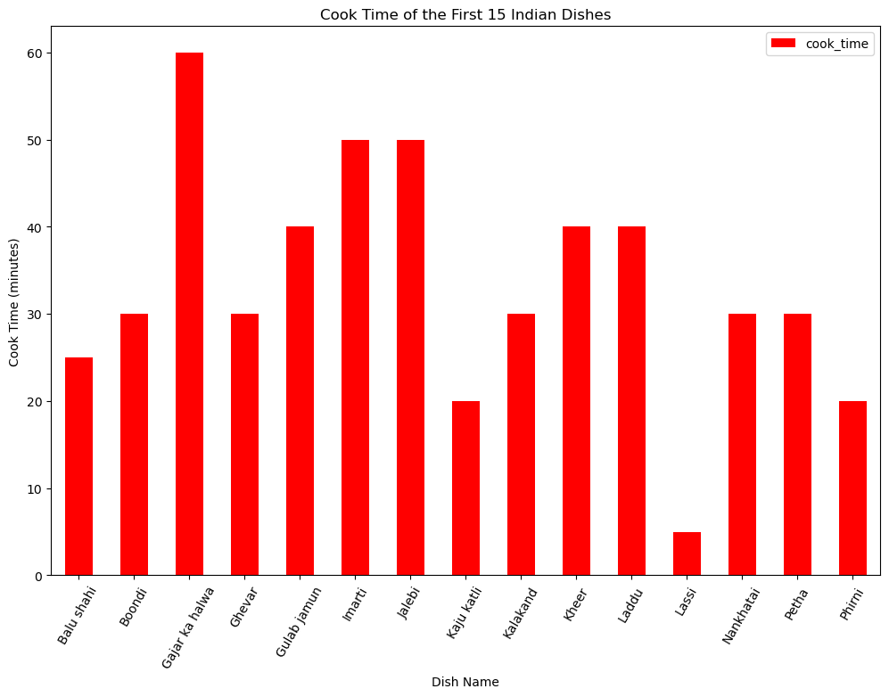

```python
import matplotlib.pyplot as plt

#Extract the first 15 dishes and their cook time
df_first_15 = df.head(15)[['name', 'cook_time']]

#Plot the data on a bar chart
df_first_15.plot(kind='bar', x='name', y='cook_time', color='red', figsize=(12, 8))
plt.xlabel("Dish Name")
plt.ylabel("Cook Time (minutes)")
plt.title("Cook Time of the First 15 Indian Dishes")
plt.xticks(rotation=60)
plt.show()
```

Using the above chat, we can identify that:

1. Most of the dishes take an average of over 20 minutes to cook
2. "Lassi" is the only dish among the chart that takes less than 10 minutes to cook
3. "Gajar ka halwa" is the item among the chart that takes the most time to cook

### Question 3: Plot both cook-time and prep-time for those 15 dishes using cluster bar chart

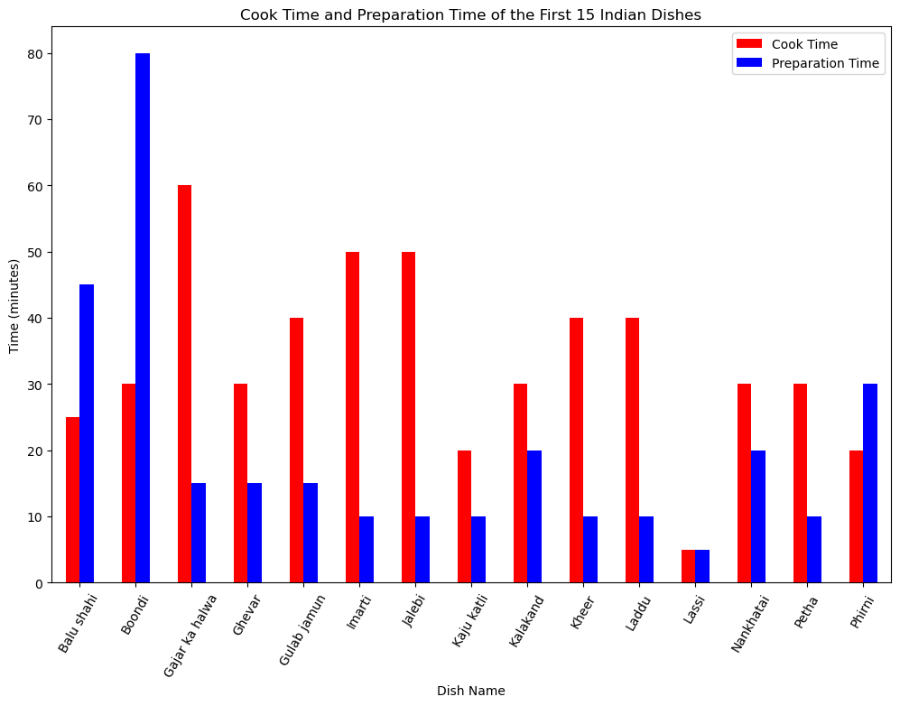

```python
#Extract the first 15 dishes and their cook time and preparation time
df_first_15 = df.head(15)[['name', 'cook_time', 'prep_time']]

#Plot the data on a clustered bar chart
df_first_15.set_index('name').plot(kind='bar', figsize=(12, 8), color=['red', 'blue'])
plt.xlabel("Dish Name")
plt.ylabel("Time (minutes)")
plt.title("Cook Time and Preparation Time of the First 15 Indian Dishes")
plt.xticks(rotation=60)
plt.legend(['Cook Time', 'Preparation Time'])
plt.show()
```

Using the above cluster bar chat, we can identify that:

1. Most of the items take less than 20 minutes in preparation as compared to cook time for the same item
2. "Boondi" takes almost more than 2x the time to prepare than to cook
3. Only "Lassi" takes almost the same time to prepare and cook
4. "Jalebi" and "Imarti" share almost the same time to cook and prepare
5. The preparation and cook time for "Lassi" remain the lowest among the 15 items from the graph

### Question 4: Which dish takes the longest time to make overall? Using stacked bar graph.

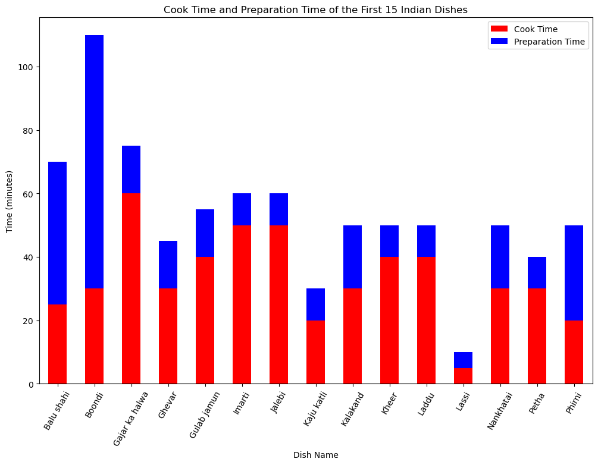

```python
#Plot the data on a stacked bar chart
df_first_15.set_index('name').plot(kind='bar', stacked=True, figsize=(12, 8), color=['red', 'blue'])
plt.xlabel("Dish Name")
plt.ylabel("Time (minutes)")
plt.title("Cook Time and Preparation Time of the First 15 Indian Dishes")
plt.xticks(rotation=60)
plt.legend(['Cook Time', 'Preparation Time'])
plt.show()
```

Using the above stacked bar graph, we can identify that:

### Question 5: Extract last 5 dishes in the dataset using cluster horizontal bar chart with the title "Dishes", with a grid, of size 5 by 6 inches, and a legend

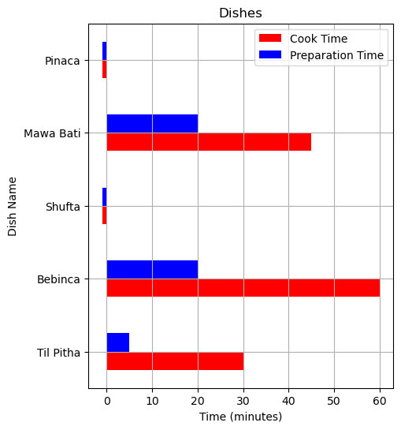

```python
#Extract the last 5 dishes and their cook time and preparation time
df_last_5 = df.tail(5)[['name', 'cook_time', 'prep_time']]

#Plot the data on a clustered horizontal bar chart
df_last_5.set_index('name').plot(kind='barh', figsize=(5, 6), color=['red', 'blue'])
plt.xlabel("Time (minutes)")
plt.ylabel("Dish Name")
plt.title("Dishes")
plt.grid(True)
plt.legend(['Cook Time', 'Preparation Time'])
plt.show()
```

### Question 6: Use column cook_time and plot using histogram, 10 bins and modify the xticks. Is column normally distributed?

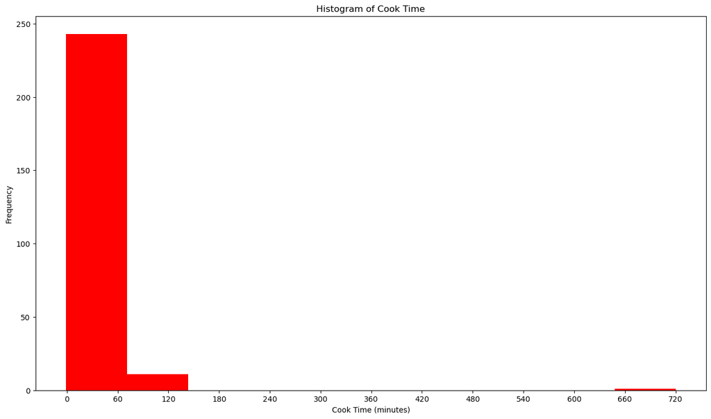

```python
#Plot the histogram of the cook time column with 10 bins and a width of 10 inches
plt.figure(figsize=(16, 9))
plt.hist(df['cook_time'], bins=10, color='red')
plt.xlabel("Cook Time (minutes)")
plt.ylabel("Frequency")
plt.title("Histogram of Cook Time")

#Modify the xticks to show only every 60 minutes
xticks = range(0, df['cook_time'].max()+60, 60)
plt.xticks(xticks)

plt.show()
```

Using the above histogram and setting the x-ticks to show only every 60 minutes, we can identify that:

1. The data is not normally distributed. The cook_time data has some outliers that can be identified on the extreme end of the chart at between 650-750 minutes
2. The data also explains that most of the food is cooked in under or close to 60 minutes

### Question 7: Addition to question 6 add another column to the histogram graph, prep_time and customize the multiple histogram (make it transparent, and use figure size 20,6)

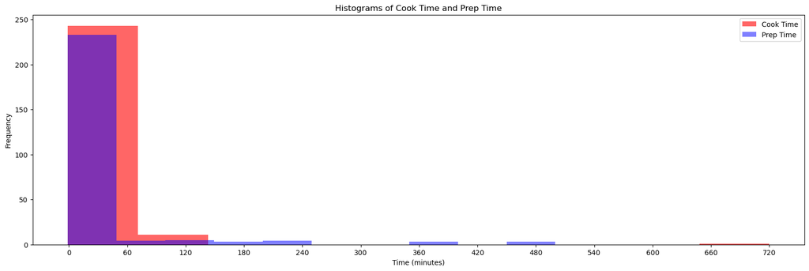

```python
#Plot two histograms of the cook time and prep time columns with 10 bins and a width of 20 inches
plt.figure(figsize=(20, 6))
plt.hist(df['cook_time'], bins=10, color='red', alpha=0.6, label='Cook Time')
plt.hist(df['prep_time'], bins=10, color='blue', alpha=0.5, label='Prep Time')
plt.xlabel("Time (minutes)")
plt.ylabel("Frequency")
plt.title("Histograms of Cook Time and Prep Time")
plt.legend()

#Modify the xticks to show only every 60 minutes
xticks = range(0, max(df['cook_time'].max(), df['prep_time'].max())+60, 60)
plt.xticks(xticks)

plt.show()
```

### Question 8: Group by prep_time and calculate the mean of cook_time and plot it on graph

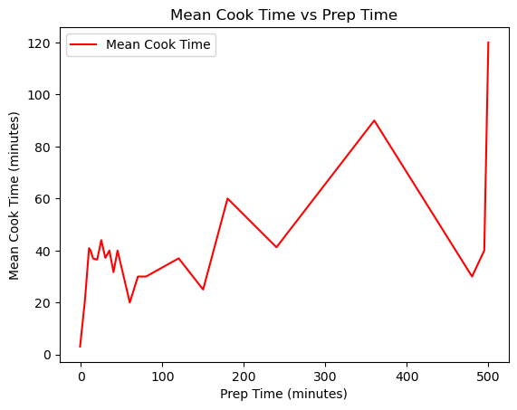

```python
#Group the data by the prep_time column and calculate the mean of the cook_time column
grouped_data = df.groupby("prep_time").mean()

#Plot the mean cook time for each group of prep time
plt.plot(grouped_data['cook_time'], label="Mean Cook Time", color="red")
plt.xlabel("Prep Time (minutes)")
plt.ylabel("Mean Cook Time (minutes)")
plt.title("Mean Cook Time vs Prep Time")
plt.legend()

plt.show()
```

### Question 9: Count different flavor profiles and plot it on the pie chart (customize the pie chart)

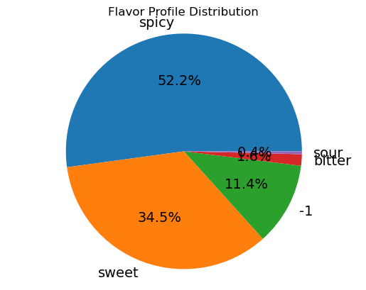

```python
#Count the number of instances of each flavor profile
flavor_counts = df['flavor_profile'].value_counts()

#Plot the flavor profile counts as a pie chart
plt.pie(flavor_counts, labels=flavor_counts.index, autopct='%1.1f%%', textprops={'fontsize': 14})
plt.axis('equal')
plt.title("Flavor Profile Distribution")

plt.show()
```

Using the above pie chart to plot the flavour counts, we can identify that:

1. Most of the food item is spicy followed by sweet
2. The -1 which accounts to 11.4% can be considered as error values since no other data information is given and flavour can not be -1
3. Since most of the food item is spicy with a majority of 52.2%, we can say that most Indians like spicy food

### Question 10: What is the relationship between the prep time and the cook time for each dish in the dataset?

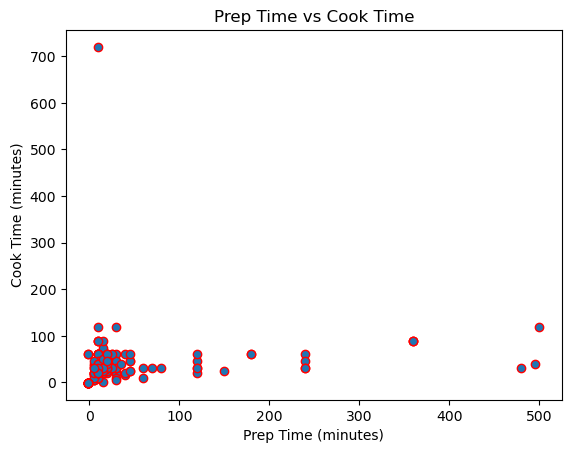

```python
#Plot a scatter plot of prep_time vs cook_time
plt.scatter(df['prep_time'], df['cook_time'], edgecolors='r')
plt.xlabel('Prep Time (minutes)')
plt.ylabel('Cook Time (minutes)')
plt.title('Prep Time vs Cook Time')

plt.show()
```

Using the above scatter plot, we can identify that the cook time remains lower even when the preparation time increases